# Comparative Genomics Southern Flounder

## Post-odering quality assessment II

### Examine pairwise linkage & Identify gaps between markers

Plot rf vs LOD

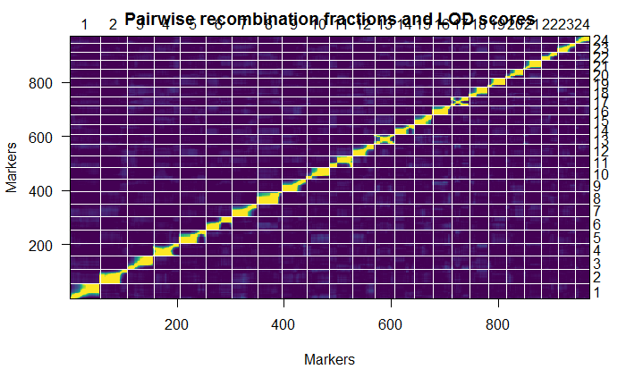

Identify large gaps between markers which is indicative of adjacent markers being only weakly linked.

```r
summaryMap(FamA_M.final)
```

```
        n.mar length ave.spacing max.spacing
1          56   61.3         1.1         6.6
2          51   62.1         1.2        11.8
3          49   61.2         1.3         7.3
4          49   79.8         1.7         8.7
5          49   75.0         1.6         9.9
6          48   81.7         1.7        14.2
7          48   56.9         1.2         8.0
8          46   58.7         1.3         8.0
9          46   60.7         1.3         5.9
10         43   59.2         1.4        12.6
11         43   88.6         2.1        42.1
12         41   48.5         1.2         7.3
13         38  108.9         2.9        19.4
14         36   61.0         1.7        14.2
15         35   50.0         1.5        14.7
16         35   53.6         1.6        15.9
17         33   98.0         3.1        19.4
18         35   46.1         1.4        10.0
19         34   62.0         1.9        17.6
20         33   57.7         1.8        13.4
21         33   57.6         1.8        17.6
22         31   57.2         1.9        10.3
23         32   54.4         1.8         7.0
24         27   48.1         1.8         9.5
overall   971 1548.2         1.6        42.1
```

Plot maps of all linkage groups:

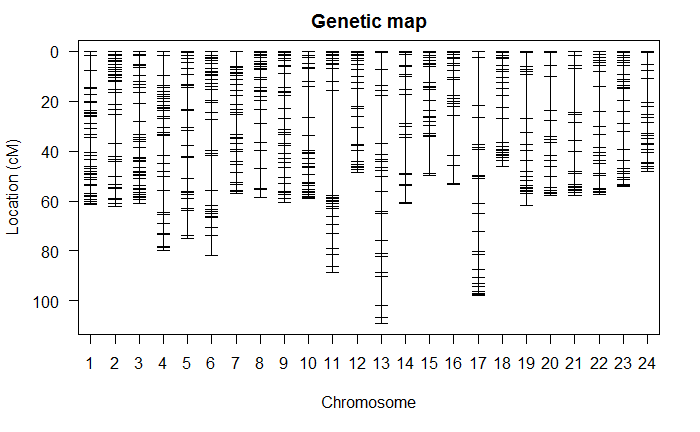

Drop markers one by one determine change in chromosome length & change in log likelihood. Identify markers that result in smaller estimated chromosome length and increased LOD.

```r
# drop each marker and compare effect
dropone <- droponemarker(FamA_M.final, maxit = 4000, tol = 1e-6,
                         error.prob = 0.001, verbose = TRUE) %>%
  add_rownames("Marker") %>%
  gather("Effect", "Change", 4:5)

# plot results
plot_dropone <- function(dropone){
  p <- ggplot(dropone, aes(x = pos, y = Change)) +
    geom_line() +
    geom_point(shape = 21, size = 2,
               color = "black", fill = "white") +
    facet_grid(Effect ~ ., scales = "free") +
    labs(x = paste("LG", dropone$chr, "Position", sep =" "), y = "Change if marker dropped") +
    theme_facet
  print(p)
}

dropone %>%
  group_by(chr) %>%
  do(plot = plot_dropone(.)) %>%
  ungroup()
```

[output not shown]

Compare effect in terms of change in length and likelihood and identify top 10 loci with strongest effect per LG.

```r
# data frame with top10 markers with strongest effect
dropone_sum <- dropone %>%
  spread("Effect", "Change") %>%
  group_by(chr) %>%
  top_n(10, LOD) %>%
  ungroup() %>%
  arrange(chr, LOD)
```

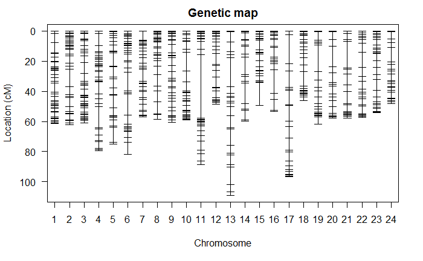

### Identify individuals with high number of XO

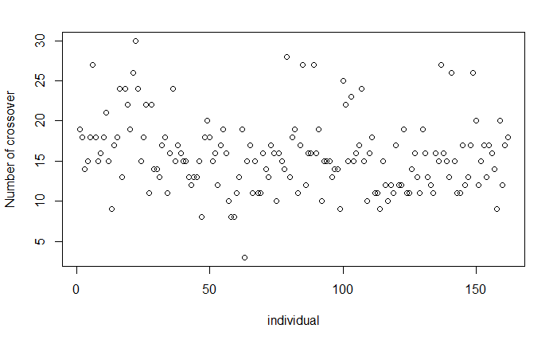

## Finalize map

Write files of finalized map. Map contains 1422 loci grouped into 24 LG.

# Compare male/female maps

## Re-insert matching loci (same segregation pattern)

Finalize the female map by inserting the loci that had duplicate segregation patterns that were previously removed.

Finalize the male map by inserting the loci that had duplicate segregation patterns that were previously removed.

```r
# import male map
FamA_M.map <- read.table("data/LINKMAP/FamA_M.map", stringsAsFactors = FALSE, header = FALSE,
                         col.names = c("LOCUS", "LG_M", "POS_M"), skip = 1)

# add duplicate loci back in
match.loci_M <- read.table("data/LINKMAP/MatchLociFamAM.txt", header = TRUE,
                         stringsAsFactors = FALSE) %>%
  left_join(FamA_M.map) %>%
  select(MATCHLOC, LG_M, POS_M) %>%
  rename(LOCUS = MATCHLOC)

# update female map
FamA_M.map <- bind_rows(FamA_M.map, match.loci_M) %>%
  group_by(LG_M) %>%
  arrange(POS_M)

write.table(FamA_M.map, file = "results/FamA_M.map",
          quote = FALSE, sep = "\t", row.names = FALSE)
```

## Compare & join male/female maps

```r
mapped_markers <- select(marker.all, LOCUS)
```

For mapping family A, the female and male maps contain 1425 and 1422 loci, respectively. Of those the 922 are shared, while the female and male maps contain 503 and 500 unique loci, respectively.

# FamA family map (onemap)

Map all loci segregating in male and/or female using full-cross.

## Filter onemap input file by markers in joined map data set

Import tab delimited onemap input file converted from filtered `*.tsv`-file using `map_convert.pl`.

```r
# change header names to Marker | Markertype | Genotype
FamA.onemap <- read.delim("data/LINKMAP/FamA.onemap", header = FALSE,
                          col.names = c("LOCUS", "LOCUSTYPE", "GENOTYPE"),
                          skip = 1, stringsAsFactors = FALSE)

# number of individuals in dataset
N <- read.delim("data/LINKMAP/FamA.onemap", header = FALSE,
                          col.names = c("N_IND", "N_LOCI"),
                          nrows = 1, stringsAsFactors = FALSE)

# keep only markers in combined data set (filter by joined data set)
Onemap.filtered <- semi_join(FamA.onemap, mapped_markers)
```

Markers with matching genotypes (same segregation pattern) are removed and stored in table with corresponding loci retained in data set to insert after mapping loci.

```r
match_loc <- anti_join(Onemap.filtered, Onemap.filt2) %>%
  rename(MATCHLOC = LOCUS) %>%
  select(MATCHLOC, GENOTYPE) %>%
  left_join(Onemap.filt2, by = "GENOTYPE") %>%
  select(LOCUS, MATCHLOC)
```

The filtered data set contains 1819 loci.

## Use onemap to create linkage map based on full-siblings

```r
FamA.Map
```

```
This is an object of class 'outcross'
    No. individuals:    174
    No. markers:        1819
    Segregation types:
       A.1: 413
       A.2: 522
       D1.10:   443
       D2.15:   441
```

Estimate two-point recombination fractions between all pairs of markers (Wu et al. 2002).

```r
# estimate recombination fraction between all pairs of markers
# creates object of class rf.2pts
FamA.Map.rf.L6.rf35 <- rf.2pts(FamA.Map, LOD = 6, max.rf = 0.35, verbose=TRUE)
```

Assign markers to linkage groups. Create sequence of all markers to assign to LGs and assign LG for LOD > 6 and rf < 0.35.

Markers are grouped into 24 LGs.

Map markers within linkage group using haldane mapping function. Onemap first creates a framework consisting of the most informative markers (segregating in both parents) and then maps the remaining markers.

```r
# define map function
set.map.fun(typ = "haldane")

# create list of separate LGs
# (convert from class group to class sequence)
LG_list <- lapply(c(1:24), function(LG) {
  make.seq(LGs, LG)
})

# uses compare() to create a framework of most informative markers
# map remaining markers using try.seq()
# this step will take a few hours
LG_ordered <- lapply((LG_list), function(LG){
  order.seq(LG, n.init=6, THRES=3, touchdown=TRUE, tol=10e-2)
})

# create marker order with all markers
LG_final <- lapply((LG_ordered), function(LG){
  make.seq(LG, "force")
})
```

## Compare alternative marker sequences

Compare alternative sequences using ripple for 4 marker window. Make changes as needed (more positive LOD indicates better sequence).

```r
# compare and display alternative orders for LG1
# prints result of each window to screen
# more positive LOD indicates better sequence
# set window size using ws, LOD sets threshold for alt orders printed

# Start writing to an output file
sink("data/LINKMAP/ripple.onemap")

# run ripple for each LG
lapply((LG_final), function(LG){
  ripple.seq(LG, ws = 4, LOD = 3, tol = 10e-2)
})

# Stop writing to the file
sink()

# change marker order if necessary for each LG# using
# LG#.new.seq <- make.seq(LGx.final, c())
# LG1.final <- map(LG#.new.seq)
```

Plot recombination fraction matrix to inspect linkage between mapped markers.

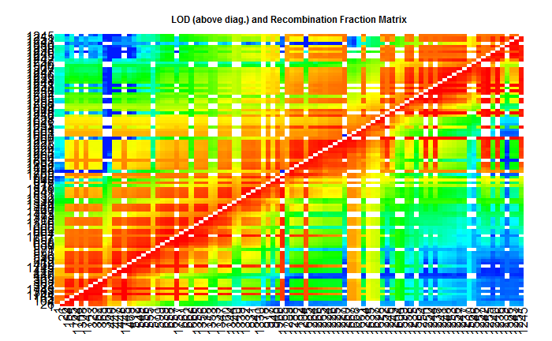

## Draw linkage map and save results

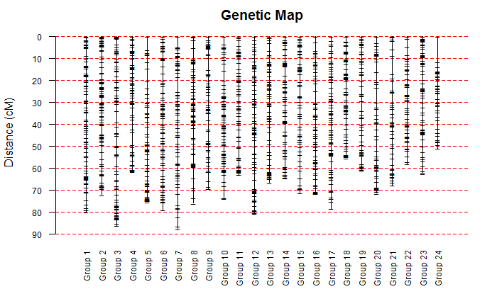

Add duplicate markers (with same genotype/segregation pattern) and save finalized map to file